# Assignment 2

Sandeep Kumar Singh, PhD

Complete all **Exercises**, and discuss answers to **Questions** in next class.

Result of final world cup of football is France- 4 and Croatia - 2. Please use control structure to print results as Team —- Wins. —– should be country name.

```r
France <- 4
Croatia <- 2

if (France < Croatia){
  print("Team Croatia Wins")
}  else {
    print("Team France Wins")
}
```

```
## [1] "Team France Wins"
```

mtcars dataset has several factor variables. However, R is reading them numeric. Please convert them into factor using a for loop. Please use column 8 to 11 for loop.

```r
str(mtcars)
```

```
## 'data.frame':    32 obs. of  11 variables:
##  $ mpg : num  21 21 22.8 21.4 18.7 18.1 14.3 24.4 22.8 19.2 ...
##  $ cyl : num  6 6 4 6 8 6 8 4 4 6 ...
##  $ disp: num  160 160 108 258 360 ...
##  $ hp  : num  110 110 93 110 175 105 245 62 95 123 ...
##  $ drat: num  3.9 3.9 3.85 3.08 3.15 2.76 3.21 3.69 3.92 3.92 ...
##  $ wt  : num  2.62 2.88 2.32 3.21 3.44 ...
##  $ qsec: num  16.5 17 18.6 19.4 17 ...
##  $ vs  : num  0 0 1 1 0 1 0 1 1 1 ...
##  $ am  : num  1 1 1 0 0 0 0 0 0 0 ...
##  $ gear: num  4 4 4 3 3 3 3 4 4 4 ...
##  $ carb: num  4 4 1 1 2 1 4 2 2 4 ...
```

```r
# mtcars$vs <- as.factor(mtcars$vs)

for (i in 8:11){
  mtcars[, i] <- as.factor(mtcars[, i])
}

str(mtcars)
```

```
## 'data.frame':    32 obs. of  11 variables:
##  $ mpg : num  21 21 22.8 21.4 18.7 18.1 14.3 24.4 22.8 19.2 ...
##  $ cyl : num  6 6 4 6 8 6 8 4 4 6 ...
##  $ disp: num  160 160 108 258 360 ...
##  $ hp  : num  110 110 93 110 175 105 245 62 95 123 ...
##  $ drat: num  3.9 3.9 3.85 3.08 3.15 2.76 3.21 3.69 3.92 3.92 ...
##  $ wt  : num  2.62 2.88 2.32 3.21 3.44 ...
##  $ qsec: num  16.5 17 18.6 19.4 17 ...
##  $ vs  : Factor w/ 2 levels "0","1": 1 1 2 2 1 2 1 2 2 2 ...
##  $ am  : Factor w/ 2 levels "0","1": 2 2 2 1 1 1 1 1 1 1 ...
##  $ gear: Factor w/ 3 levels "3","4","5": 2 2 2 1 1 1 1 2 2 2 ...
##  $ carb: Factor w/ 6 levels "1","2","3","4",..: 4 4 1 1 2 1 4 2 2 4 ...
```

Write a function to get percentage of NAs in each column using Data_set.xlsx.

```r
# Reading file
library(readxl)
library(DT)
Data_Set <- read_excel("C:/SANDEEP/GreyCampus/Statistics_class/Assignment/Assignment 2/Data_set.xlsx")

# Reading data
datatable(Data_Set)
```

|  | Year | Veh.Mfr.Code | Represented.Test.Veh.Make | Represented.Test.Veh.Model | Test.Veh.Displacement.L | Vehicle.Type | Rated.Horsepower | No.of.Cylinders.and.Rotors | Engine.Code | Tested.Transmission.Type | No.of.Gears | Transmission.Lockup. | Drive.System.Description | Transmission.Overdrive.Desc | Equivalent.Test.Weight.lbs | Axle.Ratio | N.V.Ratio | Shift.Indicator.Light.Use.Desc | Test.Procedure.Description | Test.Fuel.Type.Cd | Test.Fuel.Type.Description | Test.Category | THC | CO | CO2 | NOx | CH4 | N2O | RND_ADJ_FE | … |
| --- | --- | --- | --- | --- | --- | --- | --- | --- | --- | --- | --- | --- | --- | --- | --- | --- | --- | --- | --- | --- | --- | --- | --- | --- | --- | --- | --- | --- | --- | --- |
| 1 | 2011 | KMX | KIA | FORTE | 2 | Car | 156 | 4 | G4KD-AC | Automatic | 6 | Y | 2-Wheel Drive, Front | Top gear ration &lt; 1 | 3250 | 2.89 | 31.2 | Not eqipped | Federal fuel 2-day exhaust (w/can load) | 61 | Tier 2 Cert Gasoline | FTP | 0.0282436 | 0.1855095 | 282.3261936 | 0.0081246 | 0.0041775 |  | 31.5 | … |
| 2 | 2011 | BMX | Mini | Mini Clubman | 1.6 | Car | 122 | 4 | 1.6-A-N16-R55 | Automatic | 6 | Y | 2-Wheel Drive, Front | Top gear ration &lt; 1 | 3125 | 4.1 | 40.7 | Not eqipped | HWFE | 61 | Tier 2 Cert Gasoline | HWY | 0.00686 | 0.059 | 171.31 | 0.0012 | 0.0017 |  | 51.9 | … |
| 3 | 2010 | NSX | NISSAN | PATHFINDER SE 4X4 | 4 | Truck | 266 | 6 | AQ40DAA2 | Automatic | 5 | Y | 4-Wheel Drive | Top gear ration &lt; 1 | 5250 | 3.36 | 32.2 | Not eqipped | Federal fuel 2-day exhaust (w/can load) | 61 | Tier 2 Cert Gasoline | FTP |  |  |  |  |  |  | 17.2 | … |
| 4 | 2012 | FMX | Ford | EXPEDITION 4X2 | 5.4 | Truck | 310 | 8 | CB714B0A07 | Automatic | 6 | Y | 4-Wheel Drive | Top gear ration &lt; 1 | 6500 | 3.31 | 24.8 | Not eqipped | Federal fuel 2-day exhaust (w/can load) | 61 | Tier 2 Cert Gasoline | FTP |  |  |  |  |  |  | 16.4 | … |
| 5 | 2010 | FMX | FORD | MUSTANG V6 | 4 | Car | 210 | 6 | AZF2B60A05 | Manual | 5 | N | 2-Wheel Drive, Rear | Top gear ration &lt; 1 | 3875 | 3.31 | 30.5 | Not eqipped | Federal fuel 2-day exhaust (w/can load) | 61 | Tier 2 Cert Gasoline | FTP |  |  |  |  |  |  | 21.9 | … |
| 6 | 2011 | HNX | HONDA | ACCORD LX/EX/EX-L COUPE | 2.4 | Car | 190 | 4 | B431A1 | Automatic | 5 | Y | 2-Wheel Drive, Front | Top gear ration &lt; 1 | 3625 | 4.44 | 33.7 | Not eqipped | Federal fuel 2-day exhaust (w/can load) | 61 | Tier 2 Cert Gasoline | FTP | 0.00497 | 0.177 | 313 | 0.0094 | 0.00074 |  | 28.4 | … |
| 7 | 2010 | HNX | HONDA | ACCORD EX-L COUPE | 3.5 | Car | 268 |  | 8701A1 | Semi-Automatic | 5 | Y | 2-Wheel Drive, Front | Top gear ration &lt; 1 | 3875 | 4.31 | 34.7 | Not eqipped | HWFE | 61 | Tier 2 Cert Gasoline | HWY | 0.00309 | 0.042 | 223.3 | 0.0088 |  |  | 39.9 | … |
| 8 | 2011 | HYX | HYUNDAI | GENESIS COUPE | 2 | Car | 210 | 4 | G4KF-MC | Manual | 6 | N | 2-Wheel Drive, Rear | Top gear ration &lt; 1 | 3750 | 3.91 | 40.3 | Not eqipped | Federal fuel 2-day exhaust (w/can load) | 61 | Tier 2 Cert Gasoline | FTP | 0.0131 | 0.1954 | 340.12 | 0.017 |  |  | 26.1 | … |
| 9 | 2010 | FJX | SUBARU | IMPREZA WGN/OUTBACK SPT AWD | 2.5 | Both | 170 |  | H2.5CMF | Manual | 5 | N | 2-Wheel Drive, Front | Top gear ration &lt; 1 | 3375 | 3.9 | 42.6 | Not eqipped | HWFE | 61 | Tier 2 Cert Gasoline | HWY | 0.0006 | 0.0034 | 237.364 | 0.002 |  |  | 37.5 | … |
| 10 | 2010 | TYX | TOYOTA | FJ CRUISER 4WD | 3.956 | Truck | 260 | 6 | 09 | Automatic | 5 | Y | Part-time 4-Wheel Drive | Top gear ration &lt; 1 | 4750 | 3.73 | 29.2 | Not eqipped | Federal fuel 2-day exhaust (w/can load) | 61 | Tier 2 Cert Gasoline | FTP | 0.0407125 | 0.3023265 | 428.0108424 | 0.0174369 |  |  | 20.6 | … |

[output cut: 990 more lines]

```r
# Check is we have NA's in dataset
head(is.na(Data_Set))
```

```
##       Year Veh.Mfr.Code Represented.Test.Veh.Make Represented.Test.Veh.Model
## [1,] FALSE        FALSE                     FALSE                      FALSE
## [2,] FALSE        FALSE                     FALSE                      FALSE
## [3,] FALSE        FALSE                     FALSE                      FALSE
## [4,] FALSE        FALSE                     FALSE                      FALSE
## [5,] FALSE        FALSE                     FALSE                      FALSE
## [6,] FALSE        FALSE                     FALSE                      FALSE
##      Test.Veh.Displacement.L Vehicle.Type Rated.Horsepower
## [1,]                   FALSE        FALSE            FALSE
## [2,]                   FALSE        FALSE            FALSE
## [3,]                   FALSE        FALSE            FALSE
## [4,]                   FALSE        FALSE            FALSE
## [5,]                   FALSE        FALSE            FALSE
## [6,]                   FALSE        FALSE            FALSE
##      No.of.Cylinders.and.Rotors Engine.Code Tested.Transmission.Type
```

[output cut: 62 more lines]

```r
colSums(is.na(Data_Set))
```

```
##                           Year                   Veh.Mfr.Code
##                              0                              0
##      Represented.Test.Veh.Make     Represented.Test.Veh.Model
##                              0                              0
##        Test.Veh.Displacement.L                   Vehicle.Type
##                              0                              0
##               Rated.Horsepower     No.of.Cylinders.and.Rotors
##                              0                            139
##                    Engine.Code       Tested.Transmission.Type
##                              0                              0
##                    No.of.Gears           Transmission.Lockup.
##                              0                              0
##       Drive.System.Description    Transmission.Overdrive.Desc
##                              0                              0
##     Equivalent.Test.Weight.lbs                     Axle.Ratio
##                              0                              0
##                      N.V.Ratio Shift.Indicator.Light.Use.Desc
##                              0                              0
##     Test.Procedure.Description              Test.Fuel.Type.Cd
##                              0                              0
##     Test.Fuel.Type.Description                  Test.Category
##                              0                              0
##                            THC                             CO
##                             82                             78
##                            CO2                            NOx
##                             79                             88
##                            CH4                            N2O
##                            462                            732
##                     RND_ADJ_FE                       FE.Bag.1
##                              3                            718
##                       FE.Bag.2                       FE.Bag.3
##                            723                            762
##                  Target.Coef.A             Target.Coef.B.mph.
##                              0                              0
##            Target.Coef.C.mph.2                    Set.Coef.A.
##                              0                              0
##                Set.Coef.B.mph.               Set.Coef.C.mph.2
##                              0                              0
##       Aftertreatment.Device.Cd     Aftertreatment.Device.Desc
##                            175                            175
##       Police.Emergency.Vehicle                             ID
##                              0                              0
```

```r
# writing function to create percentage
# First step is to write a pseudo code to calculate percentage
# (sum(is.na(x))/length(x))*100
pMiss <- function(x){
  (sum(is.na(x))/length(x))*100
}

missing_perc_col <- apply(Data_Set, 2, pMiss)
head(missing_perc_col)
```

```
##                       Year               Veh.Mfr.Code
##                          0                          0
##  Represented.Test.Veh.Make Represented.Test.Veh.Model
##                          0                          0
##    Test.Veh.Displacement.L               Vehicle.Type
##                          0                          0
```

Write a function to get percentage of NAs in each row.

```r
pMiss <- function(x){
  (sum(is.na(x))/length(x))*100
}

missing_perc_row <- apply(Data_Set, 1, pMiss)
head(missing_perc_row)
```

```
## [1]  2.380952  9.523810 21.428571 21.428571 21.428571  7.142857
```

Write a function to get summary of numeric columns (use summary function) such as THC, CO, CO2 etc. in data set. In same function try to generate boxplot using base R.

```
##    Min. 1st Qu.  Median    Mean 3rd Qu.    Max.    NA's
## 0.00000 0.09222 0.21040 0.40139 0.51975 5.74290      78
```

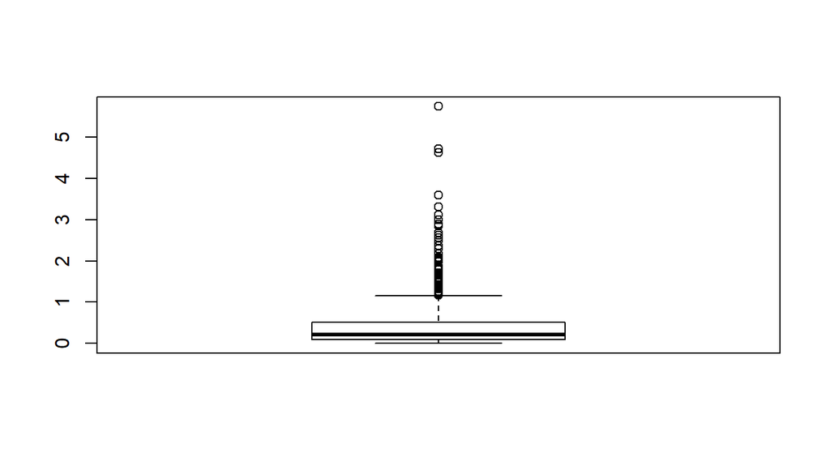

```r
Summary_data <- function(y){
  print(summary(y))
  boxplot(y) # creating box plot and checking outliers
}
Summary_data(Data_Set$CO)
```

```r
Summary_data(Data_Set$CO2)
```

```
##    Min. 1st Qu.  Median    Mean 3rd Qu.    Max.    NA's
##   121.9   249.6   327.0   347.3   418.0   794.7      79
```

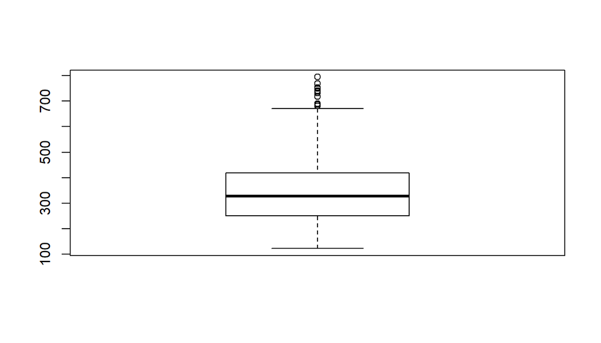

```r
Summary_data(Data_Set$THC)
```

```
##    Min. 1st Qu.  Median    Mean 3rd Qu.    Max.    NA's
## 0.00000 0.00418 0.01515 0.02959 0.03099 0.93200      82
```

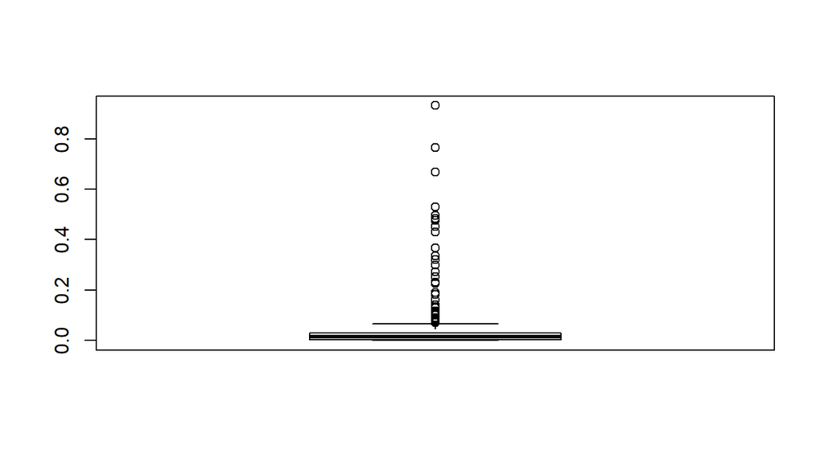

Write a function to create histograms of numeric columns such as THC, CO, CO2 etc. in data set. Use ggplot2 to generate figure.

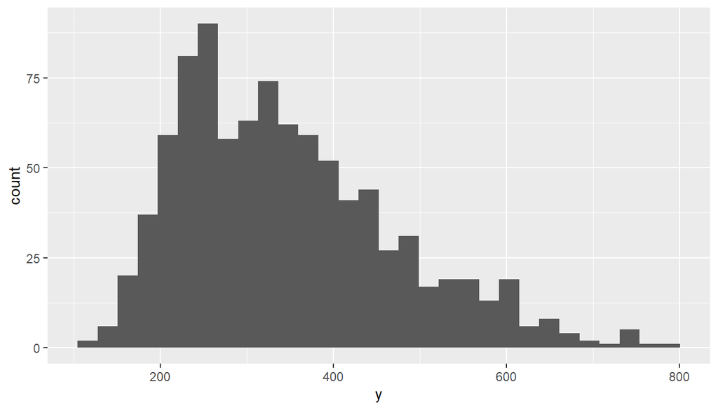

```r
library(ggplot2)
data_dis <- function(x, y){
  ggplot(x) +
    aes(y) +
    geom_histogram()
}

data_dis(Data_Set, Data_Set$CO2)
```

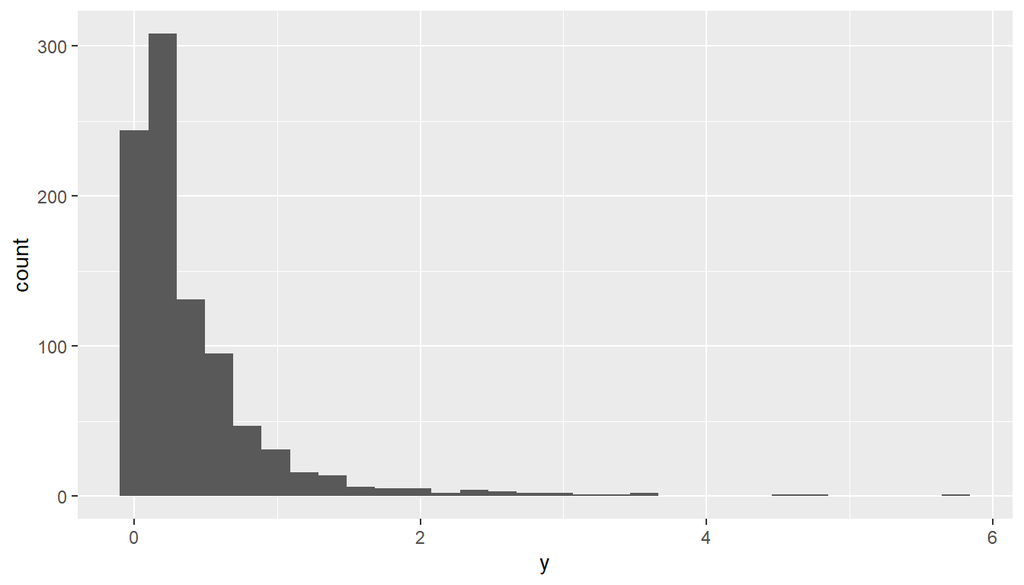

```r
data_dis(Data_Set, Data_Set$CO)
```

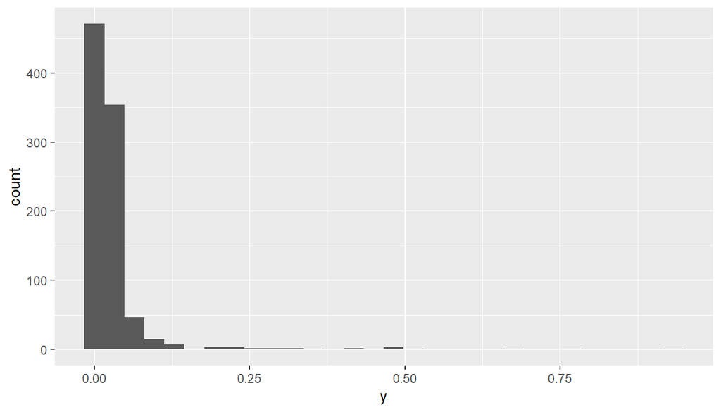

```r
data_dis(Data_Set, Data_Set$THC)
```

Data set contains date columns. All of these date columns are untidy. Please create a better formatted dataset. Date should be dd/mm/yyyy in final format. Use column 2, 3 and 5 only, using Assignment2.xlsx.

```r
library(readr)
library(tidyverse)
library(tidyr)
# Reading the data set
Date_Set <- read.csv("C:/SANDEEP/GreyCampus/Statistics_class/Assignment/Assignment 2/Assignment2.csv",
                     na.strings=c("","NA"),
                     stringsAsFactors = FALSE)

head(Date_Set)
```

```
##   FD.Amount First.FD.Date Last.FD.Date Committed.Period FD.termination.date
## 1      3000    05-01-2015   03-01-2020               60           5/31/2020
## 2      2000     6/25/2015    5/25/2020               60           6/30/2018
## 3      1000    07-01-2015   06-01-2020               60           6/30/2019
## 4      1000     6/25/2015    5/25/2020               60          10/31/2018
## 5      2000     7/15/2015    5/15/2021               71          11/30/2015
## 6      1000     4/15/2015    6/15/2020               63           3/31/2020
##   Actual.Tenure Current_Status Date.of.Birth Gender          Salary
## 1            60        Expired     11-Jun-78      M     5 - 10 lakh
## 2            36     Terminated     12-Mar-70      M     5 - 10 lakh
## 3            47     Terminated     01-May-65      0 less than 1 lac
## 4            40     Terminated     18-Apr-67      F less than 1 lac
## 5             4     Terminated          <NA>      M     5 - 10 lakh
## 6            59     Terminated     01-May-67      M less than 1 lac
```

```r
library(lubridate)

# Date_Set %>%
#   separate('First.FD.Date', c("Month", "Day", "Year")) %>% # first separate columns
#   unite(First_FD_Date, c("Day", "Month", "Year"), sep = "/") %>% # uniting them
#   separate('Last.FD.Date', c("Month", "Day", "Year")) %>%
#   unite(Last_FD_Date, c("Day", "Month", "Year"), sep = "/") %>%
#   separate('FD.termination.date', c("Month", "Day", "Year")) %>%
#   unite(FD_termination_date, c("Day", "Month", "Year"), sep = "/")

Date_Set$`First.FD.Date` <- mdy(Date_Set$`First.FD.Date`)

Date_Set$`Last.FD.Date` <- mdy(Date_Set$`Last.FD.Date`)

Date_Set$`FD.termination.date` <- mdy(Date_Set$`FD.termination.date`)


head(Date_Set)
```

```
##   FD.Amount First.FD.Date Last.FD.Date Committed.Period FD.termination.date
## 1      3000    2015-05-01   2020-03-01               60          2020-05-31
## 2      2000    2015-06-25   2020-05-25               60          2018-06-30
## 3      1000    2015-07-01   2020-06-01               60          2019-06-30
## 4      1000    2015-06-25   2020-05-25               60          2018-10-31
## 5      2000    2015-07-15   2021-05-15               71          2015-11-30
## 6      1000    2015-04-15   2020-06-15               63          2020-03-31
##   Actual.Tenure Current_Status Date.of.Birth Gender          Salary
## 1            60        Expired     11-Jun-78      M     5 - 10 lakh
## 2            36     Terminated     12-Mar-70      M     5 - 10 lakh
## 3            47     Terminated     01-May-65      0 less than 1 lac
## 4            40     Terminated     18-Apr-67      F less than 1 lac
## 5             4     Terminated          <NA>      M     5 - 10 lakh
## 6            59     Terminated     01-May-67      M less than 1 lac
```

Date of birth column contains month in string format. Please create a tidy data column with months in numeric format. Now your data should be similar to previous question.

```r
tidy_date_1 <- Date_Set %>%
  separate('Date.of.Birth', c("Day","Month", "Year")) %>%
  mutate(Yr = case_when(Year > 20 ~ '19',
                        Year <= 20 ~ '20')) %>%
  unite(Year, c("Yr", "Year"),sep = "")

head(tidy_date_1)
```

```
##   FD.Amount First.FD.Date Last.FD.Date Committed.Period FD.termination.date
## 1      3000    2015-05-01   2020-03-01               60          2020-05-31
## 2      2000    2015-06-25   2020-05-25               60          2018-06-30
## 3      1000    2015-07-01   2020-06-01               60          2019-06-30
## 4      1000    2015-06-25   2020-05-25               60          2018-10-31
## 5      2000    2015-07-15   2021-05-15               71          2015-11-30
## 6      1000    2015-04-15   2020-06-15               63          2020-03-31
##   Actual.Tenure Current_Status  Day Month Year Gender          Salary
## 1            60        Expired   11   Jun 1978      M     5 - 10 lakh
## 2            36     Terminated   12   Mar 1970      M     5 - 10 lakh
## 3            47     Terminated   01   May 1965      0 less than 1 lac
## 4            40     Terminated   18   Apr 1967      F less than 1 lac
## 5             4     Terminated <NA>  <NA> NANA      M     5 - 10 lakh
## 6            59     Terminated   01   May 1967      M less than 1 lac
```

```r
# Converting month into numerical value
tidy_date_1$Month <- match(tidy_date_1$Month, month.abb)

tidy_date_2 <- tidy_date_1 %>%
  unite(Date_of_Birth, c("Month", "Day", "Year"), sep = "/")
#
head(tidy_date_2)
```

```
##   FD.Amount First.FD.Date Last.FD.Date Committed.Period FD.termination.date
## 1      3000    2015-05-01   2020-03-01               60          2020-05-31
## 2      2000    2015-06-25   2020-05-25               60          2018-06-30
## 3      1000    2015-07-01   2020-06-01               60          2019-06-30
## 4      1000    2015-06-25   2020-05-25               60          2018-10-31
## 5      2000    2015-07-15   2021-05-15               71          2015-11-30
## 6      1000    2015-04-15   2020-06-15               63          2020-03-31
##   Actual.Tenure Current_Status Date_of_Birth Gender          Salary
## 1            60        Expired     6/11/1978      M     5 - 10 lakh
## 2            36     Terminated     3/12/1970      M     5 - 10 lakh
## 3            47     Terminated     5/01/1965      0 less than 1 lac
## 4            40     Terminated     4/18/1967      F less than 1 lac
## 5             4     Terminated    NA/NA/NANA      M     5 - 10 lakh
## 6            59     Terminated     5/01/1967      M less than 1 lac
```

```r
class(tidy_date_2$Date_of_Birth)
```

```
## [1] "character"
```

Convert all dates into Date format; they are currently in character variable format.

```r
# Due to weired NA formation, I am converting them into NA
tidy_date_2$Date_of_Birth <- gsub("NA/NA/NANA", "NA", tidy_date_2$Date_of_Birth)
tidy_date_2$Date_of_Birth <- gsub("/NA/NANA", "NA", tidy_date_2$Date_of_Birth)

head(tidy_date_2)
```

```
##   FD.Amount First.FD.Date Last.FD.Date Committed.Period FD.termination.date
## 1      3000    2015-05-01   2020-03-01               60          2020-05-31
## 2      2000    2015-06-25   2020-05-25               60          2018-06-30
## 3      1000    2015-07-01   2020-06-01               60          2019-06-30
## 4      1000    2015-06-25   2020-05-25               60          2018-10-31
## 5      2000    2015-07-15   2021-05-15               71          2015-11-30
## 6      1000    2015-04-15   2020-06-15               63          2020-03-31
##   Actual.Tenure Current_Status Date_of_Birth Gender          Salary
## 1            60        Expired     6/11/1978      M     5 - 10 lakh
## 2            36     Terminated     3/12/1970      M     5 - 10 lakh
## 3            47     Terminated     5/01/1965      0 less than 1 lac
## 4            40     Terminated     4/18/1967      F less than 1 lac
## 5             4     Terminated            NA      M     5 - 10 lakh
## 6            59     Terminated     5/01/1967      M less than 1 lac
```

```r
# Character variable into Date format
tidy_date_2$First.FD.Date <- as.Date(tidy_date_2$First.FD.Date, format = "%d/%m/%Y")
tidy_date_2$Last.FD.Date <- as.Date(tidy_date_2$Last.FD.Date, format = "%d/%m/%Y")
tidy_date_2$FD.termination.date <- as.Date(tidy_date_2$FD.termination.date, format = "%d/%m/%Y")
tidy_date_2$Date_of_Birth <- as.Date(tidy_date_2$Date_of_Birth, format = "%d/%m/%Y")
class(tidy_date_2$First_FD_Date)
```

```
## [1] "NULL"
```

```r
#
# head(tidy_date_2)
```

Create a new column age based on date of birth column and First FD column. Date format is necessary to do basic arithmetic.

```r
tidy_date_3 <- tidy_date_2 %>%
  mutate(Age = (First.FD.Date - Date_of_Birth)/365) %>%
  separate(Age, (c("Age", "Decimal"))) %>%
  select(-("Decimal"))
head(tidy_date_3)
```

```
##   FD.Amount First.FD.Date Last.FD.Date Committed.Period FD.termination.date
## 1      3000    2015-05-01   2020-03-01               60          2020-05-31
## 2      2000    2015-06-25   2020-05-25               60          2018-06-30
## 3      1000    2015-07-01   2020-06-01               60          2019-06-30
## 4      1000    2015-06-25   2020-05-25               60          2018-10-31
## 5      2000    2015-07-15   2021-05-15               71          2015-11-30
## 6      1000    2015-04-15   2020-06-15               63          2020-03-31
##   Actual.Tenure Current_Status Date_of_Birth Gender          Salary  Age
## 1            60        Expired    1978-11-06      M     5 - 10 lakh   36
## 2            36     Terminated    1970-12-03      M     5 - 10 lakh   44
## 3            47     Terminated    1965-01-05      0 less than 1 lac   50
## 4            40     Terminated          <NA>      F less than 1 lac <NA>
## 5             4     Terminated          <NA>      M     5 - 10 lakh <NA>
## 6            59     Terminated    1967-01-05      M less than 1 lac   48
```